# Statistical Inference Course Project

This project involves in the investigation of exponential distribution in R and comparing it with the Central Limit Theorem.The exponential distribution is simulated in R with rexpn(n,lambda)where lambda is the parameter.The value of lambda is set to 0.2 for all the simulations.The mean and standarad deviation of the exponential distribution is 1/lambda.The distribution of the averages of 40 exponentials is studied on a thousand simulations.

Our results will show:

1.The Sample mean and compare it to the theoritical mean of the distribution. 2.Show how variable the sample is and compare it to the theoritical variance of the distribution. 3.Show that the distribution is approximately normal.

**Required packages**

*For this analysis we will use ggplot2package.*

### SIMULATIONS

```r
lambda = 0.2
n = 40
nsims = 1:1000
set.seed(820)
means <- data.frame(x = sapply(nsims, function(x) {mean(rexp(n, lambda))}))
head(means)
```

```
##          x
## 1 5.750000
## 2 3.808205
## 3 4.058154
## 4 3.999241
## 5 4.312532
## 6 4.418246
```

**Sample mean of 1000 simulations of 40 random samples of exponential distribution is**

```r
mean(means$x)
```

```
## [1] 4.998812
```

**Expected mean of an exponential distribution of lambda is**

```r
mu=1/lambda
print(mu)
```

```
## [1] 5
```

**Standarad Deviation of the simulated means**

```r
sd(means$x)
```

```
## [1] 0.7909422
```

**Expected standard deviation**

```r
(1/lambda)/sqrt(40)
```

```
## [1] 0.7905694
```

**Variance of our simulations:**

```r
var(means$x)
```

```
## [1] 0.6255895
```

**Expected variance**

```r
((1/lambda)/sqrt(40))^2
```

```
## [1] 0.625
```

Mean of the distribution is 4.9988. Expected mean is 5. The mean of the means of the exponential of 1000 simulations of 40 exponential(0.2)s is 4.9988, which is very close to the expected mean of 1/0.2 = 5.0. The standard deviation of 0.7909 is also close to the expected standard deviation of 0.79056. The Variance of the expected standarad deviation and variance of the simulated mean are close.

Below is a histogram plot of the means of the 1000 simulations of rexp(n, lambda). It is overlaid with a normal distribution with mean 5 and standard deviation 0.7909. The distribution of our simulations definetly appears normal

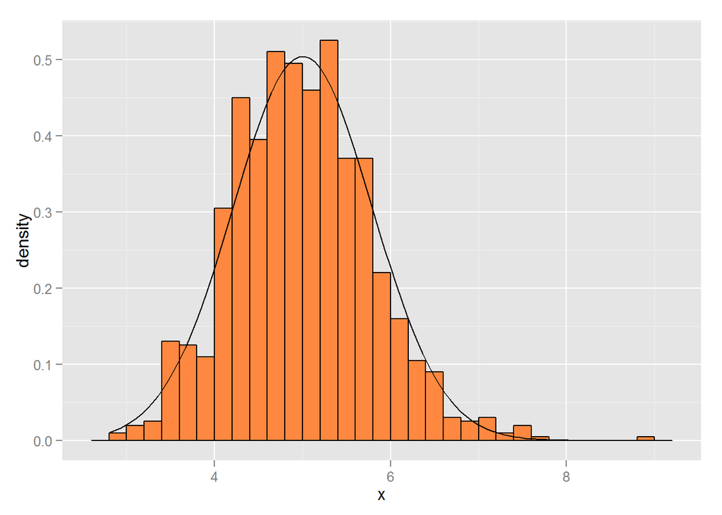

```r
library(ggplot2)
ggplot(data = means, aes(x = x)) +
geom_histogram(aes(y=..density..), fill = I('#ff8840'),
binwidth = 0.20, color = I('black')) +
stat_function(fun = dnorm, arg = list(mean = 5, sd = sd(means$x)))
```